# Connect1-Stigma: Missing data imputation

#### Percentage of missing data in each variable

```
##                 Variable PercentMissing
## 1                    Age           0.00
## 2        PTA4_better_ear           0.00
## 3             HHIE_total           5.09
## 4                Ability           3.72
## 5                    Sex           0.00
## 6                    Edu           1.07
## 7                Married          13.32
## 8                 Health           1.79
## 9                    QoL           1.36
## 10       Help_neighbours           1.07
## 11         Help_problems           1.29
## 12               Concern           3.22
## 13                Lonely           1.07
## 14                Accomp           1.07
## 15           Sub_Age_avg           2.15
## 16        Age_stigma_avg           3.72
## 17         HA_stigma_avg           1.29
## 18        Soc_Suspect_HL           4.37
## 19           Soc_Know_HL           4.23
## 20        Soc_Discuss_HL           5.95
## 21      Soc_Hearing_test           9.24
## 22         Soc_Obtain_HA           5.23
## 23     Soc_Sometimes_use           9.38
## 24       Soc_Regular_use           7.09
## 25     Soc_Very_positive           9.74
## 26 Soc_Somewhat_positive          11.10
## 27 Soc_Somewhat_negative          10.82
## 28     Soc_Very_negative          11.82
## 29          Purchased_HA           0.00
```

#### Percentage of missing data for each participant

```
##    NumberCellsMiss ParticipantCount PercentCellsMiss ParticipantPercent
## 1                0              753             0.00              53.94
## 2                1              322             3.57              23.07
## 3                2              121             7.14               8.67
## 4                3               49            10.71               3.51
## 5                4               37            14.29               2.65
## 6                5               26            17.86               1.86
## 7                6               21            21.43               1.50
## 8                7                7            25.00               0.50
## 9                8               10            28.57               0.72
## 10               9               10            32.14               0.72
## 11              10                4            35.71               0.29
## 12              11                9            39.29               0.64
## 13              12               14            42.86               1.00
## 14              13                9            46.43               0.64
## 15              14                1            50.00               0.07
## 16              15                2            53.57               0.14
## 17              16                1            57.14               0.07
```

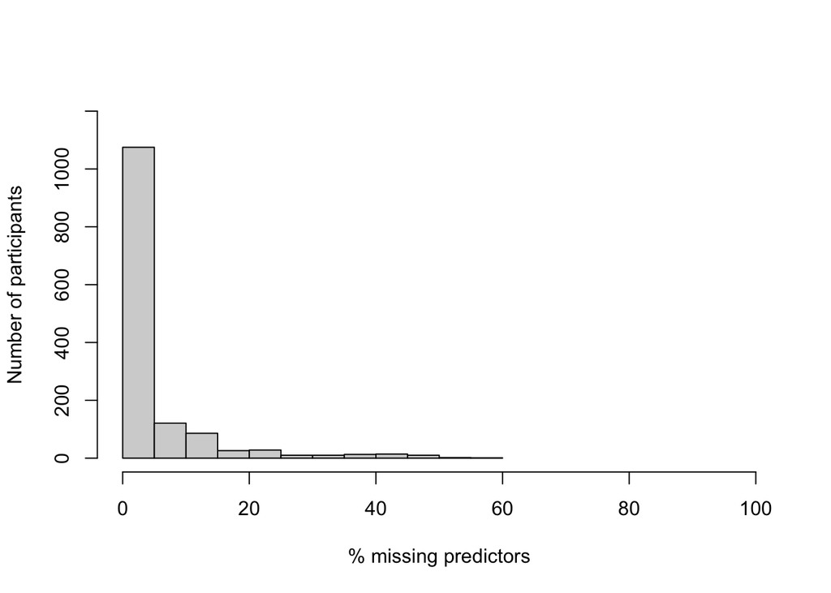

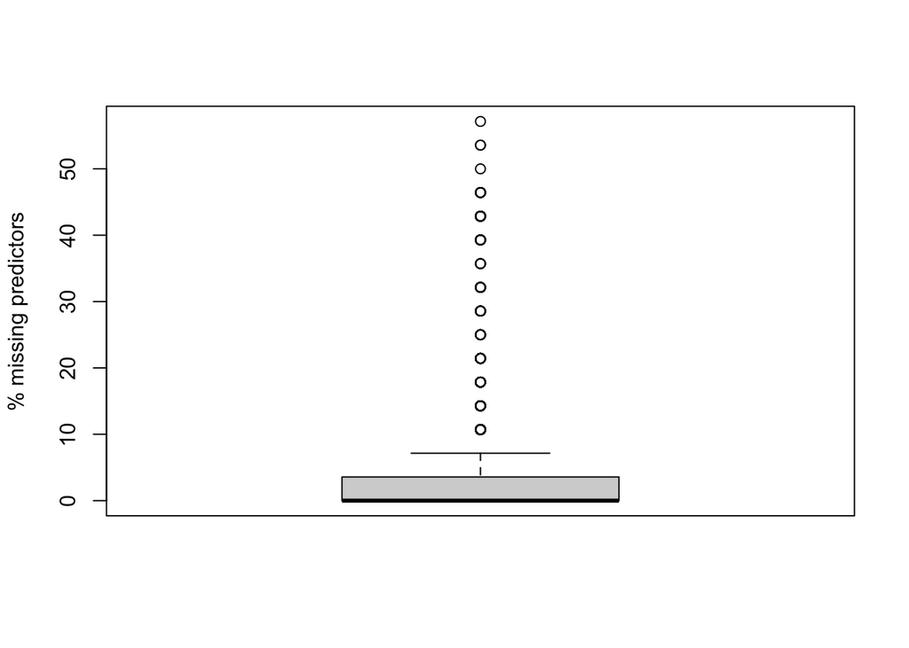

#### Missing data imputation

Missing data were imputed using a random forest algorithm from the R package *missForest* (version 1.4; Stekhoven, 2016). The parameters used were mtry = 7 and ntree = 500, with all other parameters set to default. This algorithm was chosen over others such as Multiple Imputation By Chained Equations and k-Nearest Neighbors because it gave the best estimates of missing values across multiple test datasets with artificially missing data, and it makes no assumptions about the distributions of variables or the linearity of relationships between variables (Stekhoven & Buhlmann, 2012). The parameters of mtry = 7 and ntree = 500 were chosen based on tests with the current dataset, examining how combinations of these two parameters affected prediction error. The maximum number of trees tested was capped at 500 and the number of predictors per tree was capped at 9 to limit computational time, after it was shown that there was little gain in model performance beyond 500 trees.

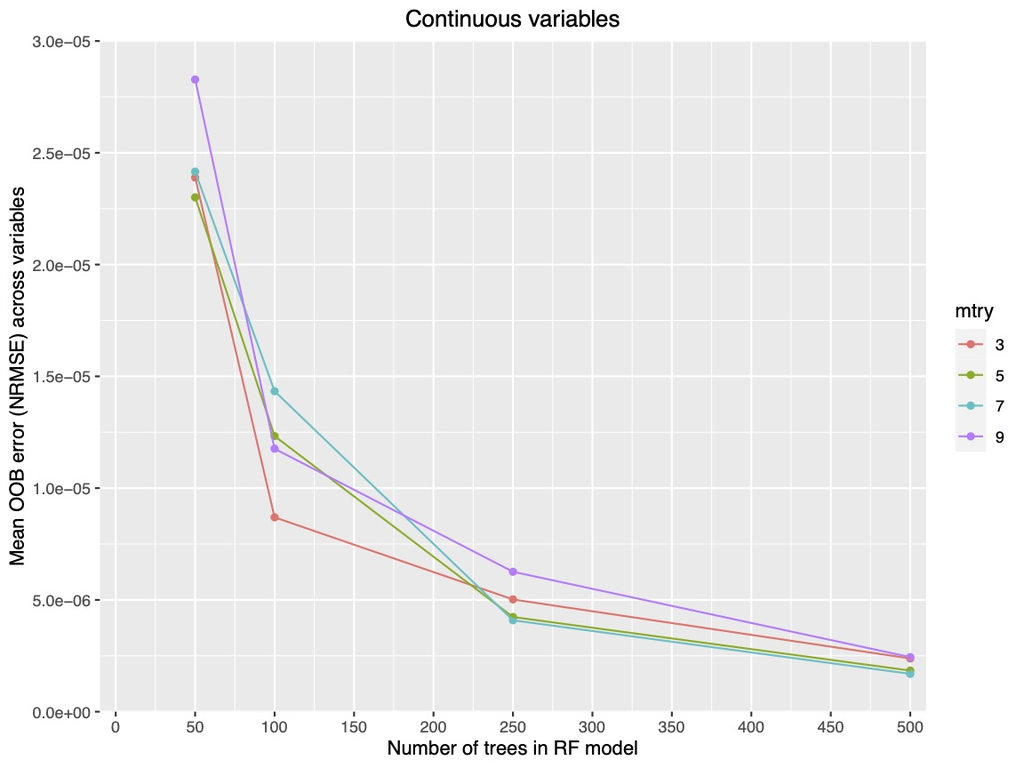

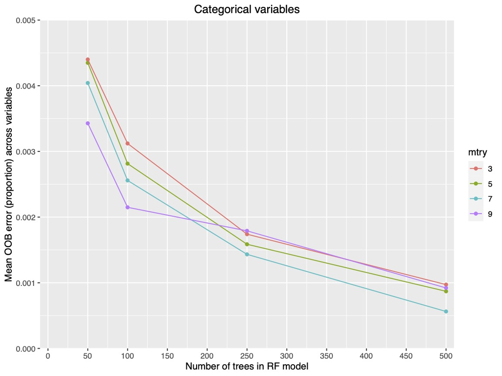

The dataset used for imputation consisted of 1396 observations of 28 variables. Using this algorithm, variables were first ordered according to how much missing data they had, from the least amount of missing data to the most. For each variable in turn, from the ‘x’ with the least amount of missing data to the ‘x’ with the most, a random forest model was created using the parameters of mtry and ntree to predict the missing values of the first ‘x’ from other x’s, using complete observations. After the first pass of the algorithm, the resulting data matrix was compared to an initial data matrix where missing values were temporarily filled in with means or modes. The algorithm repeated the process of using complete data to predict missing data using the newly-filled cells until the difference between the old and new data matrices stopped decreasing and started increasing (or until a specified number of passes was reached; the default in this case was 10 iterations).

**Distributions of original data with missing values, and new data with imputed missing values**

[figure not shown]